# Ptychodera Cisreg Development: Cis-regulatory network Graph Analysis

Alberto Perez-Posada

4/01/2023

## About

In this markdown, we will analyse the networks of TF/target gene cis-regulatory interactinos generated using ANANSE.

We will load these networks as tabular data that we will transform into `igraph` graph objects, that we can parse and annotate using our information on TF classes and other similar functional annotation that we have carried out over the course of this project.

## Load libraries

```r
library(DESeq2)
library(limma)
library(ComplexHeatmap)
library(circlize)
library(ggplot2)
library(igraph)
```

## Load functions

```r
source("code/r_code/r_functions/sourcefolder.R")

sourceFolder(
  "code/r_code/r_functions",
  recursive = TRUE
  )

sourceFolder(
  "code/r_code/r_general",
  recursive = TRUE
  )
```

## Load previous Data

We will need some of the information we have generated in our previous analyses such as stage-specific cluster information and Transcription factor annotation.

```r
# RNA clusters
load("outputs/rda/stage_specific_clusters.rda")

# Transcription Factor information
load("outputs/rda/TF_annotation.rda")
```

## Load and prepare information for graph analysis

Here we will load all the remaining information of our interest and we will transform it into a format compliant to some of the functions we have made to annotate the graphs; basically, tabular data with gene id <–> annotation category.

```r
# Transcription factors

allTFclasses_col <- c(topclasses_col,otherclasses_col)

pfla_tfs_graph_analysis <-
  merge(
    pfla_tfs,
    data.frame(
      TFclass =
        c(names(topclasses_col),names(otherclasses_col)),
      col =
        c(topclasses_col,otherclasses_col)
      ),
    by.x = 2,
    by.y = 1
  )[,c(2,1,3)]

colnames(pfla_tfs_graph_analysis) <- c("id","TFclass","col")

# Effector genes
pfla_tfeg <- data.frame(
  id = allgenes,
  TFEG = ifelse(allgenes %in% pfla_tfs$id, "TF", "EG")
)

# Functional categories (COG)
pfla_funcat <- read.table(
  "/home/ska/aperpos/Def_Pfla/outputs/eggnog/20221014_ptyFlav3_CYi_longest.cds.fa.transdecoder.pep_eggnog_meNOG_all.emapper.annotations.COG.tsv",
  col.names = c("id","funcat")
)

# Trans-developmental / housekeeping
pfla_td_nohk <-
  unique(
    read.table(
      "/home/ska/aperpos/Def_Pfla/outputs/identif_tf_transdev/transdev/20210507_transdev_expanded_exclusive_nonhk.tsv",
      header=F,
      stringsAsFactors = F)[,1]
    )

pfla_hk_notd <-
  unique(
    read.table(
      "/home/ska/aperpos/Def_Pfla/outputs/identif_housekeeping_genes/20210507_housekeep_custom_exclusive_nontd.tsv",
      header=F,
      stringsAsFactors=F)[,1]
    )

pfla_tdhk <- data.frame(
  id = allgenes,
  TDHK =
    ifelse(allgenes %in% pfla_td_nohk, "td",
    ifelse(allgenes %in% pfla_hk_notd, "hk",
    "none")
    )
  )
```

Finally, we add them into a list that our function for annotation will iterate through. We will call this the **list of attributes**

```r
pfla_attributes_list <-
  list(
    pfla_tfeg,
    pfla_tfs_graph_analysis,
    pfla_funcat,
    pfla_tdhk
    )
```

We will also load the GO annotation of Ptychodera to use it later on in the functions.

```r
#gene universe
gene_universe <- allgenes

# gene-GO mappings
pfla_id_GO <-
  readMappings(
    "outputs/functional_annotation/go_blast2go/GO_annotation.txt"
  )
```

Likewise, we will also load the EggNOG annotation of gene names for more clarity in the plots of the graphs.

```r
pfla_genenames <-
  read.delim2(
    file = "/home/ska/aperpos/Def_Pfla/outputs/eggnog/venog_all/ptyFlav3_CYi_longest.cds.fa.transdecoder.pep_eggnog_veNOG_all.emapper.annotations",
    skip = 3,
    header = TRUE
  )[,c(1,5,13)]
pfla_genenames <- pfla_genenames[pfla_genenames$predicted_gene_name != "",]
```

## Load ANANSE outputs

Here we will use the function `LoadNetworkData` that reads the .network file replacing instances of em dash and other ANANSE-related quirks. The resulting dataframe has three columns: “tf” (transcription factor), “tg” (target gene), and “prob” (probability). We manually add back underscores to the gene ids because ANANSE required the gene ids in a different format.

We do this for both the Early Blastula (EB) and Late Gastrula (LG) networks.

```r
# EARLY BLASTULA
pfla_EB_nw <- LoadNetworkData("/home/ska/aperpos/Def_Pfla/outputs/ananse/20210901_EB.network")
pfla_EB_nw$tf <- gsub("TCONS", "TCONS_", pfla_EB_nw$tf)
pfla_EB_nw$tg <- gsub("TCONS", "TCONS_", pfla_EB_nw$tg)

# LATE GASTRULA
pfla_LG_nw <- LoadNetworkData("/home/ska/aperpos/Def_Pfla/outputs/ananse/20210908_LG.network")
pfla_LG_nw$tf <- gsub("TCONS", "TCONS_", pfla_LG_nw$tf)
pfla_LG_nw$tg <- gsub("TCONS", "TCONS_", pfla_LG_nw$tg)
```

Here it is what it looks like.

```r
head(pfla_EB_nw)
```

```
##                tf             tg       prob
## 1: TCONS_00000165 TCONS_00000001 0.13640409
## 2: TCONS_00000165 TCONS_00000003 0.11046195
## 3: TCONS_00000165 TCONS_00000004 0.10880337
## 4: TCONS_00000165 TCONS_00000006 0.09827907
## 5: TCONS_00000165 TCONS_00000007 0.09742769
## 6: TCONS_00000165 TCONS_00000008 0.17221461
```

## Early Blastula

The first thing we will do is filter the network and keep only those interactions whose values are in the top 5% percentile. We will use this later on to quantify and measure the In- and Out-Degree of each gene, among other things.

```r
pfla_EB_nw2 <- FilterNetwork(pfla_EB_nw,q=0.95)
```

```
## [1] "Original network is 35854 genes. Filtered network is 8256 genes."
```

We generate an `igraph` object using our custom wrapper `GenerateNetwork` that also filter by the same number of interactions, since we provide `q = 0.95`.

```r
pfla_EB_graph <- GenerateNetwork(pfla_EB_nw,q = 0.95)
```

Using our list of attributes, we add this information to all the pertinent nodes (== genes) of our network using our ParseNetwork function.

```r
pfla_EB_parsenetwork <- ParseNetwork(pfla_EB_graph, pfla_attributes_list)
```

The resulting object can be subsetted to extract the new network with attributes on one object and the data frame of attributes on the other.

```r
pfla_EB_graph2 <- pfla_EB_parsenetwork[[1]]
pfla_EB_df_attr <- pfla_EB_parsenetwork[[2]]
```

The data frame of attributes is a data.frame object sorted in the same order as nodes are indexed in the igraph object. The content of this data frame is, for every node that has an attribute, a row with the id of this node, the index of this node, and a bunch of attributes (color, whether it is a trans-developmental gene, TF class, functional category, etc.)

```r
head(pfla_EB_df_attr)
```

```
##               id index TFEG     TFclass             col funcat TDHK
## 1 TCONS_00001049     1   TF       T-box         #f38d97      K none
## 2 TCONS_00001141     2   TF     C2H2_ZF         #ffebb5      K none
## 3 TCONS_00001174     3   TF        Runt lightgoldenrod2      Z none
## 4 TCONS_00001304     4   TF     C2H2_ZF         #ffebb5      O   td
## 5 TCONS_00001709     5   TF Homeodomain         #5a5a82        none
## 6 TCONS_00001951     6   TF         Pou     chartreuse2      K none
```

Finally, we use our wrapper `NetworkStats`.

This wrapper performs a number of calculations using our igraph object and the tabular data frame, including also the gene ontology of target genes, and also reports the top central genes, the centrality of different kinds of genes by attribute (e.g. centrality of genes by TF class).

The inputs of the function are:

- nw: the network represented as a tabular factor/target/prob
- graph: the igraph object representing the network
- att: a data frame containing information about the nodes of the network (e.g., the gene class, the gene function category, etc.)
- N: the number of top nodes to select
- C: a parameter to select the connected component of the graph to analyze
- gene_universe: the universe of genes to consider in the gene ontology (GO) analysis
- id2go: a mapping between gene IDs and GO IDs

The function outputs a list containing various statistics and metrics of the network, such as the number of genes, the number of active TFs, the top emitters and receivers of the network, the number of self-regulated TFs, the size of the connected components of the graph, the centrality of the TFs and the functional categories, and the gene ontology information.

```r
pfla_EB_stats <- NetworkStats(pfla_EB_nw2, pfla_EB_graph2, pfla_EB_df_attr, N = 10, gene_universe = gene_universe, id2go = pfla_id_GO)
```

```
## [1] "Basic Stats"
## [1] "Components"
## [1] "13"
## [1] "Centrality and category-based metrics"
## [1] "Centrality"
## [1] "Centrality of TFs"
## [1] "Centrality of Trans-Devs"
## [1] "Edges of Functional Categories"
## [1] "Centrality of Functional Categories"
## [1] "Getting Gene Ontology"
## [1] "Starting analysis 1 of 5"
```

[output not shown]

[output not shown]

[output not shown]

[output not shown]

[output not shown]

[output not shown]

[output not shown]

[output not shown]

[output not shown]

[output not shown]

[output not shown]

[output not shown]

[output not shown]

[output not shown]

[output not shown]

[output not shown]

[output not shown]

[output not shown]

[output not shown]

[output not shown]

[output not shown]

[output not shown]

[output not shown]

[output not shown]

[output not shown]

```
## [1] "Starting analysis 2 of 5"
```

[output not shown]

[output not shown]

[output not shown]

[output not shown]

[output not shown]

[output not shown]

[output not shown]

[output not shown]

[output not shown]

[output not shown]

[output not shown]

[output not shown]

[output not shown]

[output not shown]

[output not shown]

[output not shown]

[output not shown]

[output not shown]

[output not shown]

[output not shown]

[output not shown]

[output not shown]

[output not shown]

[output not shown]

[output not shown]

```
## [1] "Starting analysis 3 of 5"
```

[output not shown]

[output not shown]

[output not shown]

[output not shown]

[output not shown]

[output not shown]

[output not shown]

```
## [1] "Starting analysis 4 of 5"
```

[output not shown]

[output not shown]

[output not shown]

[output not shown]

[output not shown]

[output not shown]

[output not shown]

[output not shown]

[output not shown]

[output not shown]

[output not shown]

[output not shown]

[output not shown]

[output not shown]

[output not shown]

[output not shown]

[output not shown]

[output not shown]

[output not shown]

[output not shown]

[output not shown]

[output not shown]

[output not shown]

[output not shown]

[output not shown]

[output not shown]

[output not shown]

```
## [1] "Starting analysis 5 of 5"
```

[output not shown]

[output not shown]

[output not shown]

[output not shown]

[output not shown]

[output not shown]

[output not shown]

[output not shown]

[output not shown]

[output not shown]

[output not shown]

[output not shown]

[output not shown]

[output not shown]

[output not shown]

[output not shown]

[output not shown]

[output not shown]

[output not shown]

[output not shown]

[output not shown]

[output not shown]

[output not shown]

[output not shown]

[output not shown]

[output not shown]

[output not shown]

```
## [1] "Generating output"
```

## Late Gastrula

Next we do the same for the Late Gastrula Network. We start by filtering the Network:

```r
pfla_LG_nw2 <- FilterNetwork(pfla_LG_nw,q=0.95)
```

```
## [1] "Original network is 35854 genes. Filtered network is 8543 genes."
```

Then we also generate an `igraph` network using the same percentile.

```r
pfla_LG_graph <- GenerateNetwork(pfla_LG_nw,q = 0.95)
```

We parse this graph using our list of attributes

```r
pfla_LG_parsenetwork <- ParseNetwork(pfla_LG_graph, pfla_attributes_list)

pfla_LG_graph2 <- pfla_LG_parsenetwork[[1]]
pfla_LG_df_attr <- pfla_LG_parsenetwork[[2]]
```

And finally we calculate the stats and metrics of this network:

```r
pfla_LG_stats <- NetworkStats(pfla_LG_nw2, pfla_LG_graph2, pfla_LG_df_attr, N = 10, gene_universe = gene_universe, id2go = pfla_id_GO)
```

```
## [1] "Basic Stats"
## [1] "Components"
## [1] "24"
## [1] "Centrality and category-based metrics"
## [1] "Centrality"
## [1] "Centrality of TFs"
## [1] "Centrality of Trans-Devs"
## [1] "Edges of Functional Categories"
## [1] "Centrality of Functional Categories"
## [1] "Getting Gene Ontology"
## [1] "Starting analysis 1 of 5"
```

[output not shown]

[output not shown]

[output not shown]

[output not shown]

[output not shown]

[output not shown]

[output not shown]

[output not shown]

[output not shown]

[output not shown]

[output not shown]

[output not shown]

[output not shown]

[output not shown]

[output not shown]

[output not shown]

[output not shown]

[output not shown]

[output not shown]

[output not shown]

[output not shown]

[output not shown]

[output not shown]

[output not shown]

[output not shown]

```
## [1] "Starting analysis 2 of 5"
```

[output not shown]

[output not shown]

[output not shown]

[output not shown]

[output not shown]

[output not shown]

[output not shown]

[output not shown]

[output not shown]

[output not shown]

[output not shown]

[output not shown]

[output not shown]

[output not shown]

[output not shown]

[output not shown]

[output not shown]

[output not shown]

[output not shown]

[output not shown]

[output not shown]

[output not shown]

[output not shown]

[output not shown]

[output not shown]

```
## [1] "Starting analysis 3 of 5"
```

[output not shown]

[output not shown]

[output not shown]

[output not shown]

[output not shown]

[output not shown]

[output not shown]

```
## [1] "Starting analysis 4 of 5"
```

[output not shown]

[output not shown]

[output not shown]

[output not shown]

[output not shown]

[output not shown]

[output not shown]

[output not shown]

[output not shown]

[output not shown]

[output not shown]

[output not shown]

[output not shown]

[output not shown]

[output not shown]

[output not shown]

[output not shown]

[output not shown]

[output not shown]

[output not shown]

[output not shown]

[output not shown]

[output not shown]

[output not shown]

[output not shown]

[output not shown]

[output not shown]

```
## [1] "Starting analysis 5 of 5"
```

[output not shown]

[output not shown]

[output not shown]

[output not shown]

[output not shown]

[output not shown]

[output not shown]

[output not shown]

[output not shown]

[output not shown]

[output not shown]

[output not shown]

[output not shown]

[output not shown]

[output not shown]

[output not shown]

[output not shown]

[output not shown]

[output not shown]

[output not shown]

[output not shown]

[output not shown]

[output not shown]

[output not shown]

[output not shown]

[output not shown]

[output not shown]

```
## [1] "Generating output"
```

## Comparing the networks

We will have a look at the output of these wrappers a bit later. We will now compare these two networks using the NetworkStats and the filtered tab-format networks that we have generated.

Part of this comparison involves defining a subset of genes of interest, which we load here.

```r
genes_postgr <-
  rownames(pfla_rna_dev)[
    pfla_rna_dev$cID > 12
    ]
```

And another part is loading the results of running ANANSE influence, which takes into account differential gene expression to infer the responsible factors for changes in the networks of cis-regulatory interactions between two states (in our case, the transition from early blastula to late gastrula).

```r
ananse_EB_to_LG <-
  read.table("/home/ska/aperpos/Def_Pfla/outputs/ananse/20210909_ANANSE_EG_EB",header=T) #change this path

ananse_EB_to_LG$factor <-
  sub("TCONS","TCONS_",ananse_EB_to_LG$factor)
```

The `compareNetworks` wrapper compares two networks, nw_a and nw_b, and their respective graphs, graph_a and graph_b, and outputs various metrics, visualizations, and data frames.

The function requires the following arguments:

- `nw_a`: A data frame or network object for network A.
- `nw_b`: A data frame or network object for network B.
- `graph_a`: A graph object for network A.
- `graph_b`: A graph object for network B.
- `stats_a`: A list of statistics for network A. Generated using NetworkStats() as explained above.
- `stats_b`: A list of statistics for network B. Generated using NetworkStats() as explained above.
- `influence`: if present, it outputs subgraphs of, and visualisations of, the top factors explaining the transition (as estimated by ANANSE influence).
- `name_network_a`: The name of network A. The default is “a”.
- `name_network_b`: The name of network B. The default is “b”.
- `col_a`: The color of network A in the Venn diagram. The default is “darkorange”.
- `col_b`: The color of network B in the Venn diagram. The default is “purple”.
- `geneset_interest`: if present, it compares the percentage of a set of genes of interest as targets in each of the networks.
- `top`: The proportion of top targets in each network to consider. The default is 0.9.
- `tfs`: Not used in the function.
- `gene_universe`: A vector of all genes.
- `id2go`: A data frame containing gene ontology (GO) annotations.

The function performs the following tasks:

- Identifies the exclusive and common targets in each network, and creates a Venn diagram of the targets.
- Determines the GO terms for the exclusive and common targets and returns the topGO Fisher’s test (elim method vs the whole set of ptychodera genes)
- Calculates various metrics for the two networks, such as the number of genes, active transcription factors (TFs), connections per TF and target gene (TG), and self-regulated TFs, and creates a data frame of the calculated metrics.
- Merges the InVsOut (In-degree vs. Out-degree) behavior of genes in both networks.
- Calculates the centrality of common genes in both networks, and creates a data frame of the centrality metrics.
- Calculates the centrality of TFs in both networks, and creates a data frame of the centrality metrics.
- Calculates the centrality of trans-dev (trans-developmental) genes in both networks, and creates a data frame of the centrality metrics.
- It generates sub-graphs of each of the networks, with the transcription factors found to have differences in centrality between each network.
- Some of the output plots are:
- barplots of the metrics,
- venn diagram of shared target genes across networks,
- scatter plots of centrality of common genes across networks, including TFs, and trans-dev genes,
- plots of foldchanges of centrality of genes across networks, including TFs, and trans-dev genes,
- plots of foldchanges of in-outdegree gene behavior across networks,
- sub-graphs of top central tfs on each network,
- scatter plot of top factors from ANANSE influence,
- sub graph of the network b factor using the top factors from ANANSE influence.

```r
pdf(file = "graphics/EB_LG_comparenetworks.pdf",he=8,wi=10)
EB_vs_LG <- compareNetworks(
  name_network_a = "EB",
  name_network_b = "LG",
  nw_a = pfla_EB_nw2,
  nw_b = pfla_LG_nw2,
  top = 0.9,
  stats_a = pfla_EB_stats,
  stats_b = pfla_LG_stats,
  graph_a = pfla_EB_graph2,
  graph_b = pfla_LG_graph2,
  influence = ananse_EB_to_LG,
  tfs = pfla_tfs_graph_analysis,
  geneset_interest = genes_postgr,
  id2go = pfla_id_GO,
  gene_universe = gene_universe,
  col_a = "#efaa90",
  col_b = "#fbcf99"
)
```

```
## [1] "Defining exclusive and common targets"
## [1] "getting GO terms"
## [1] "Starting analysis 1 of 3"
```

[output not shown]

[output not shown]

[output not shown]

[output not shown]

[output not shown]

[output not shown]

[output not shown]

[output not shown]

[output not shown]

[output not shown]

[output not shown]

[output not shown]

[output not shown]

[output not shown]

[output not shown]

[output not shown]

[output not shown]

[output not shown]

[output not shown]

[output not shown]

[output not shown]

[output not shown]

[output not shown]

[output not shown]

[output not shown]

[output not shown]

```
## [1] "Starting analysis 2 of 3"
```

[output not shown]

[output not shown]

[output not shown]

[output not shown]

[output not shown]

[output not shown]

[output not shown]

[output not shown]

[output not shown]

[output not shown]

[output not shown]

[output not shown]

[output not shown]

[output not shown]

[output not shown]

[output not shown]

[output not shown]

[output not shown]

[output not shown]

[output not shown]

[output not shown]

[output not shown]

[output not shown]

[output not shown]

[output not shown]

[output not shown]

```
## [1] "Starting analysis 3 of 3"
```

[output not shown]

[output not shown]

[output not shown]

[output not shown]

[output not shown]

[output not shown]

[output not shown]

[output not shown]

[output not shown]

[output not shown]

[output not shown]

[output not shown]

[output not shown]

[output not shown]

[output not shown]

[output not shown]

[output not shown]

[output not shown]

[output not shown]

[output not shown]

[output not shown]

[output not shown]

[output not shown]

[output not shown]

[output not shown]

[output not shown]

```
## [1] "Dataframe of various metrics"
## [1] "Gene Behaviour across networks"
## [1] "Gene centrality of ALL common genes across networks"
## [1] "Gene centrality of TFs across networks"
## [1] "Gene centrality of trans-dev genes across networks"
## [1] "Graph generation - TF genes"
## [1] "Graph generation - Trans-dev genes"
## [1] "Plots"
## [1] "Mean connections per TF gene"
```

```
## [1] "Number of self-regulating TFs"
```

```
## [1] "connections per target gene"
```

```
## [1] "Venn Diagram Plot"
```

```
## [1] "Number of genes of interest in targets"
```

```
## [1] "Gene Behaviour plot"
```

```
## [1] "Gene Behaviour Box plot"
```

```
## [1] "Changes in centrality for ALL genes"
```

```
## [1] "Changes in centrality for TF genes"
```

```
## [1] "Foldchange in centrality of TFs"
```

```
## [1] "graph plots of TFs that change"
```

```
## [1] "Changes in trans-dev centrality across networks"
```

```
## [1] "Foldchange % emitted connections per gene"
```

```
## [1] "graph plots of trans-dev that change"
```

```
## [1] "Influence"
```

```
## [1] "Influence graph"
```

```
## [1] "Plot influence graph"
```

```r
dev.off()
```

## Network plots

We can use the wrapper `NetworkPlots` to generate ALL of these plots together. The `CompareNetworks` wrapper will also generate plots into a file if we run the whole function inside a call to a pdf device, as done above.

```r
pdf(file = "graphics/EB_graph_plots.pdf",he=20,wi=20)

NetworkPlots(
  stats = pfla_EB_stats,
  nw = pfla_EB_nw,
  tfcol = allTFclasses_col,
  layout = TRUE,
  pdf = F
)

dev.off()
```

```r
pdf(file = "graphics/LG_graph_plots.pdf",he=20,wi=20)

NetworkPlots(
  stats = pfla_LG_stats,
  nw = pfla_LG_nw,
  tfcol = allTFclasses_col,
  layout = TRUE,
  pdf = F
)

dev.off()
```

Although these plots have been saved in disk, for clarity, we will explore these analyses by re-plotting them here. We will define the constants of colors.

```r
col_a = "#efaa90"
col_b = "#fbcf99"
```

We start by having a look at the number of connections per target gene. This is done by counting the number of instances of each gene in the “target” column of the tabular networks.

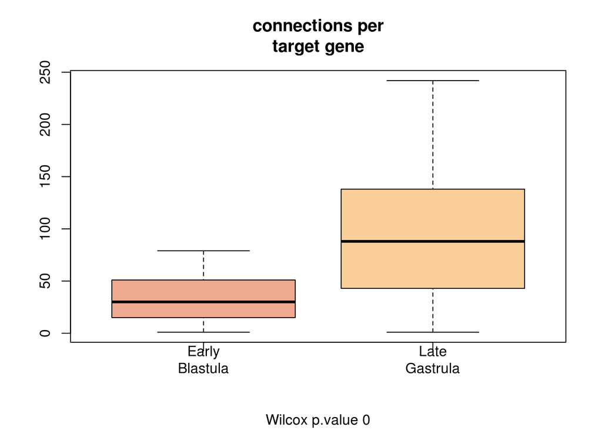

```r
# num connections per target gene
boxplot(
  main = "connections per\ntarget gene",
  list(
    c(EB_vs_LG$connections_per_tgt_gene$connects_per_tgt_gene_a),
    c(EB_vs_LG$connections_per_tgt_gene$connects_per_tgt_gene_b)
  ),
  names = c("\nEarly\nBlastula", "\nLate\nGastrula"),
  col = c(col_a,col_b),
  sub = paste0(
    "Wilcox p.value ",
    wilcox.test(
      x = c(EB_vs_LG$connections_per_tgt_gene$connects_per_tgt_gene_a),
      y = c(EB_vs_LG$connections_per_tgt_gene$connects_per_tgt_gene_b)
    )$p.value
  )
)
```

We can also have a look at the number of TFs that are self-regulated on each network by counting the number of times a given TF gene appears as a target of itself in the tabular networks.

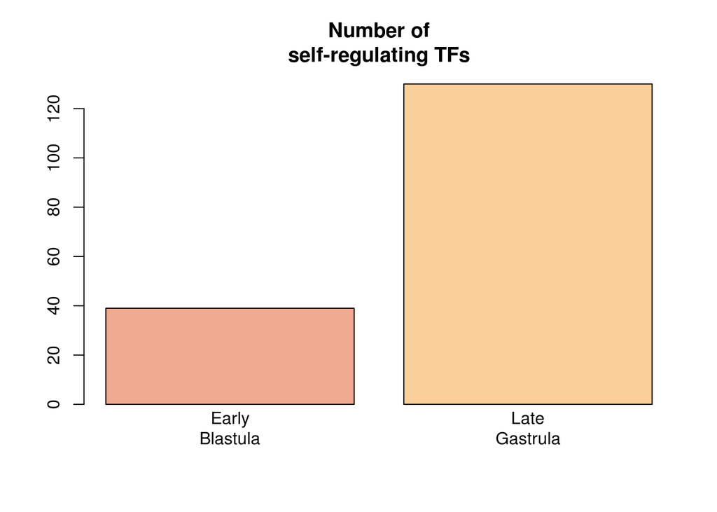

```r
# Number of self-reg TFs
barplot(
  main = "Number of\nself-regulating TFs",
  height = c(
    EB_vs_LG$comparison_table$a[EB_vs_LG$comparison_table$metric == "Num Self-Regulated TFs"],
    EB_vs_LG$comparison_table$b[EB_vs_LG$comparison_table$metric == "Num Self-Regulated TFs"]
  ),
  names.arg = c("Early\nBlastula", "Late\nGastrula"),
  col = c(col_a,col_b),
)
```

How different are these networks at the target level? We can dig into this by looking at how overlapped these networks are, and at the enriched GO terms in the exclusive and commonly-shared target genes of each network.

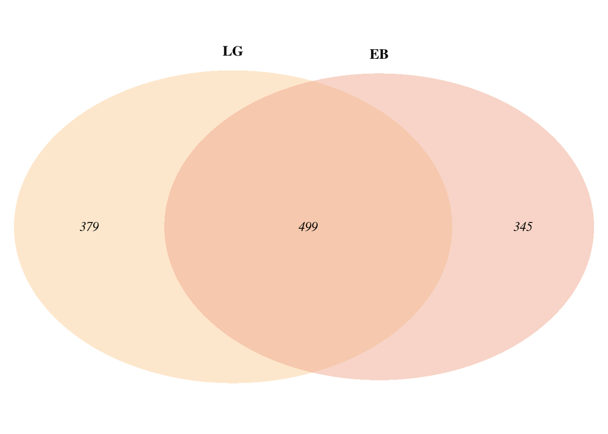

```r
# number of shared targets
x <-
  list(
    EB = c(
      EB_vs_LG$target_genes$targets_common_ab,
      EB_vs_LG$target_genes$targets_exclusive_a
      ),
    LG = c(
      EB_vs_LG$target_genes$targets_common_ab,
      EB_vs_LG$target_genes$targets_exclusive_b
      )
  )

# Helper function to display Venn diagram
display_venn <- function(x, ...){
  library(VennDiagram)
  grid.newpage()
  venn_object <- venn.diagram(x, filename = NULL, ...)
  grid.draw(venn_object)
}

# Display the plot directly in R:
display_venn(
  x,
  # Circles
  lwd = 2,
  lty = 'blank',
  fill = c(col_a, col_b),
  # Numbers
  cex = .9,
  fontface = "italic",
  # Set names
  category.names = c("EB" , "LG"),
  cat.cex = 1,
  cat.pos = 180,
  cat.fontface = "bold",
  cat.default.pos = "outer"
  )
```

Here we have the enriched GO terms for the target genes exclusive to EB, the target genes exclusive to LG, and the common ones.

```r
# GO barplots or just the words for them
EB_vs_LG$GOs_targets$GOtable$targets_exclusive_a
```

```
##         GO.ID
## 1  GO:0045892
## 2  GO:0009953
## 3  GO:0045893
## 4  GO:0000122
## 5  GO:1904668
## 6  GO:0045944
## 7  GO:1904589
## 8  GO:1903715
## 9  GO:0034622
## 10 GO:0071481
## 11 GO:0060425
## 12 GO:0060027
## 13 GO:0048286
## 14 GO:0032436
```

[output cut: 69 more lines]

```r
EB_vs_LG$GOs_targets$GOtable$targets_exclusive_b
```

```
##         GO.ID                                                      Term
## 1  GO:0003310                         pancreatic A cell differentiation
## 2  GO:0042472                                   inner ear morphogenesis
## 4  GO:0048485                    sympathetic nervous system development
## 5  GO:0045229             external encapsulating structure organization
## 6  GO:0021877                          forebrain neuron fate commitment
## 7  GO:0030335                     positive regulation of cell migration
## 8  GO:0045665             negative regulation of neuron differentiation
## 9  GO:0000122 negative regulation of transcription by RNA polymerase II
## 10 GO:0030500                         regulation of bone mineralization
## 11 GO:0008347                                      glial cell migration
## 12 GO:0001764                                          neuron migration
## 13 GO:0021987                               cerebral cortex development
## 14 GO:0014898          cardiac muscle hypertrophy in response to stress
## 15 GO:0003334                                  keratinocyte development
```

[output cut: 31 more lines]

```r
EB_vs_LG$GOs_targets$GOtable$targets_common_ab
```

```
##         GO.ID
## 1  GO:0051668
## 2  GO:0032525
## 3  GO:0045944
## 4  GO:0048025
## 5  GO:0000381
## 6  GO:0048147
## 7  GO:0008103
## 8  GO:0008285
## 9  GO:0035722
## 10 GO:0007430
## 11 GO:0000184
## 12 GO:0001745
## 13 GO:0000122
## 16 GO:0002181
```

[output cut: 69 more lines]

How are these changes in target genes achieved? What is happening at the factor level?

For this we can look at the changes in centrality for different genes across networks.

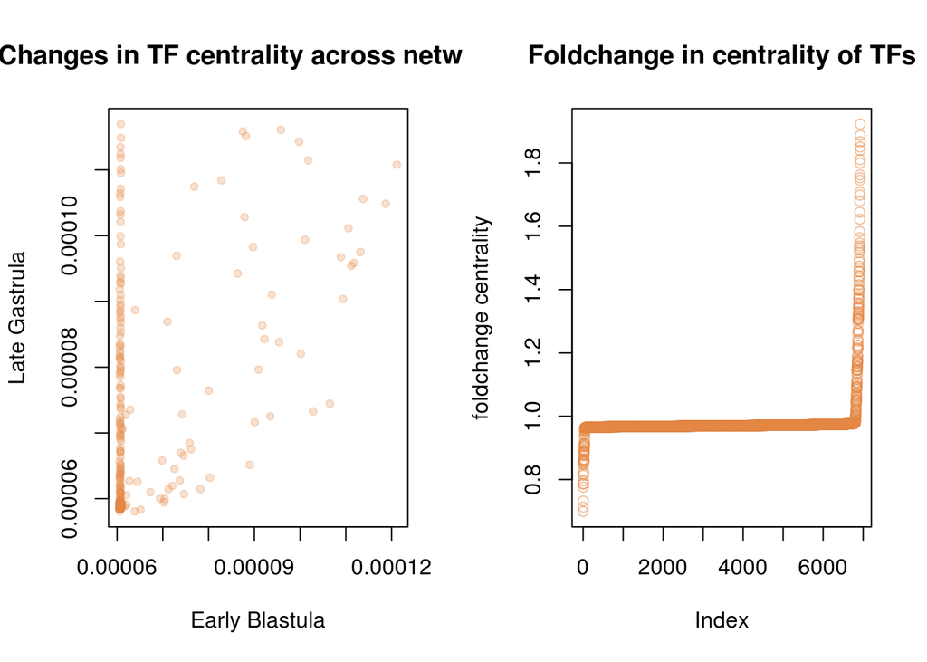

```r
# plots of correlation changes in centrality tfs and transdev
par(mfrow = c(1,2))
plot(
  main = "Changes in TF centrality across networks",
  x = EB_vs_LG$tf_centrality_across_networks$a,
  y = EB_vs_LG$tf_centrality_across_networks$b,
  xlab = "Early Blastula",
  ylab = "Late Gastrula",
  pch = 19,
  cex = 0.75,
  col = alpha("#E58745",0.25)
)

plot(
  main = "Foldchange in centrality of TFs",
  sort(
    EB_vs_LG$tf_centrality_across_networks$b /
    EB_vs_LG$tf_centrality_across_networks$a
    ),
  col = alpha("#E58745",0.5),
  ylab = "foldchange centrality"
)
```

```r
par(mfrow = c(1,1))
```

And the same about trans-dev genes:

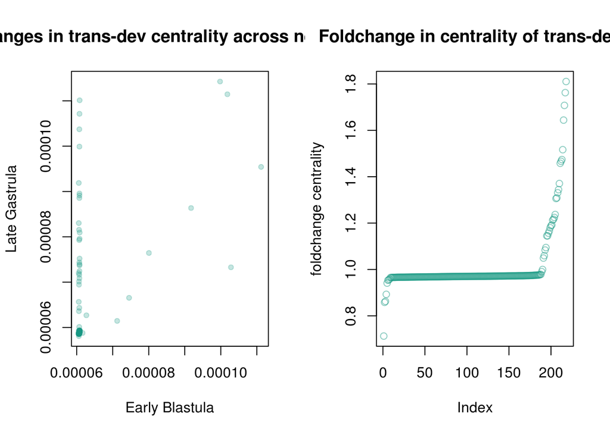

```r
par(mfrow = c(1,2))
# same in transdev
plot(
  main = "Changes in trans-dev centrality across networks",
  x = EB_vs_LG$transdev_centrality_across_networks$a,
  y = EB_vs_LG$transdev_centrality_across_networks$b,
  xlab="Early Blastula",
  ylab = "Late Gastrula",
  pch = 19,
  cex = 0.75,
  col = alpha("#1A9A83",0.25)
)

plot(
  main = "Foldchange in centrality of trans-devs",
  sort(
    EB_vs_LG$transdev_centrality_across_networks$b /
      EB_vs_LG$transdev_centrality_across_networks$a
  ),
  col = alpha("#1A9A83",0.5),
  ylab = "foldchange centrality"
)
```

```r
par(mfrow = c(1,1))
```

This is also reflected at the InvsOut-Degree of genes, what we call “gene behaviour”, and how it changes between networks. This can be visualised as cumulative density functions and/or boxplots.

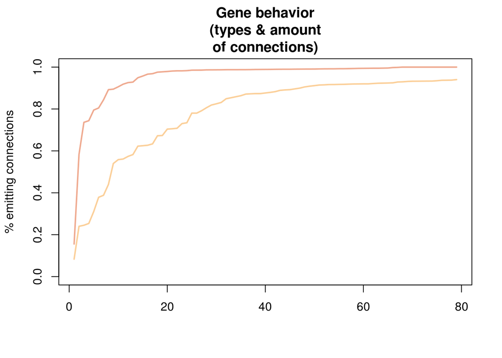

```r
eb_inout_ratio <-
  pfla_EB_stats$In_Out_per_Gene$ratio[
    pfla_EB_stats$In_Out_per_Gene$ratio > 0
    ]

lg_inout_ratio <-
  pfla_LG_stats$In_Out_per_Gene$ratio[
    pfla_LG_stats$In_Out_per_Gene$ratio > 0
  ]

plot(
  seq(1:length(eb_inout_ratio)),
  eb_inout_ratio,
  main = "Gene behavior\n(types & amount\nof connections)",
  col = col_a,
  type = "l",
  xlab = "",
  ylab = "% emitting connections",
  lwd = 2,
  ylim = c(0,1)
)

lines(
  seq(1:79),
  lg_inout_ratio[1:79],
  main = "Gene behavior\n(types & amt of connections)",
  col = col_b,
  lwd = 2
)
```

To have a better idea of what are these TF genes, and since we saw that there is a TF switch at the transcriptional level during development (see previous markdowns), we can showcase the changes in the network structure by looking at the centrality of the different genes by TF class.

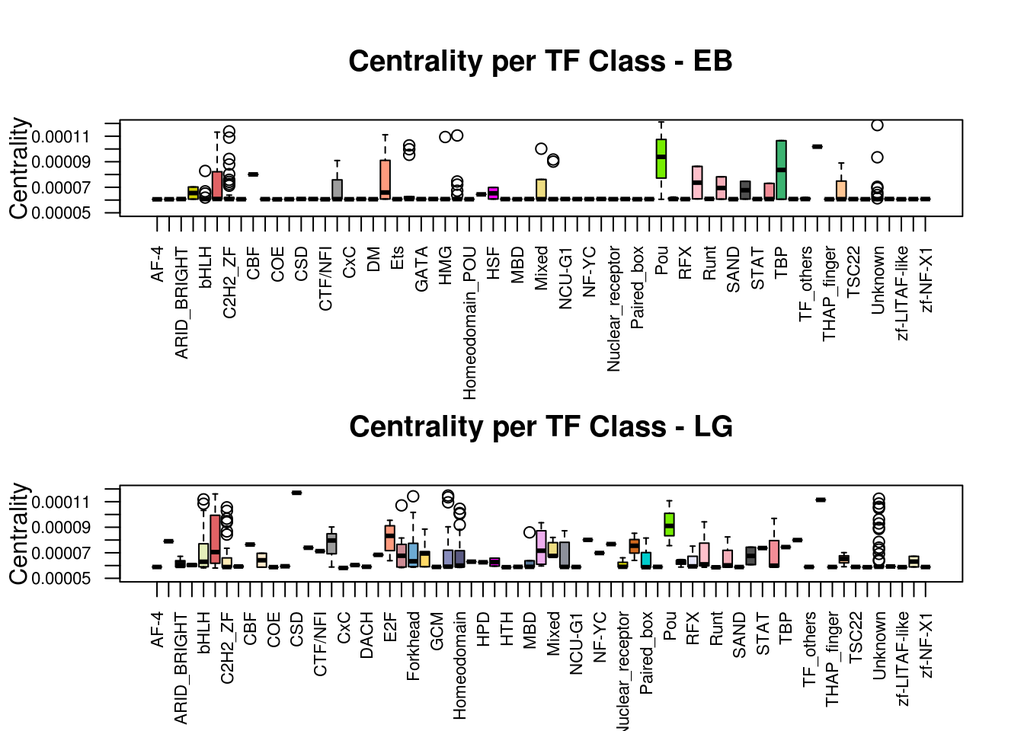

```r
## Centrality per TF class

par(mfrow = c(2,1))
plot_centrality_TFclass(
  s = pfla_EB_stats$Centrality_per_TFclass,
  f = allTFclasses_col,
  # sub_s = topclasses,
  main = "Centrality per TF Class - EB",
  ylim = c(0.00005,0.00012)
)

plot_centrality_TFclass(
  s = pfla_LG_stats$Centrality_per_TFclass,
  f = allTFclasses_col,
  # sub_s = topclasses,
  main = "Centrality per TF Class - LG",
  ylim = c(0.00005,0.00012)
)
```

```r
par(mfrow = c(1,1))
```

Another way to check for differences between target genes in networks is looking at the presence of certain genes of interest in each. For example, we can check how many genes of larval development are being targeted in each of the networks. We see there is a large different in the proportion of larval genes that are embedded in the LG network compared to the EB network. This is hinting at the aforementioned switch towards larval development already taking place at the cis-regulatory level during gastrulation.

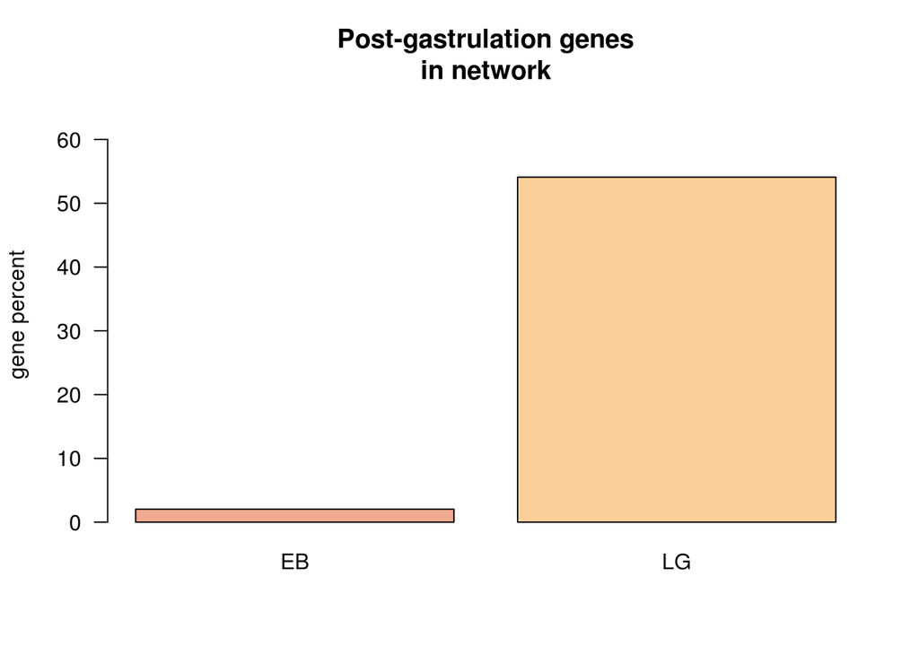

```r
# number of post-gastrulation genes in network

barplot(
  main="Post-gastrulation genes\nin network",
  height=c(
    EB_vs_LG[[11]][1]/length(EB_vs_LG$target_genes$targets_exclusive_a)*100,
    EB_vs_LG[[11]][2]/length(EB_vs_LG$target_genes$targets_exclusive_b)*100
  ),
  col = c(
    col_a,
    col_b
  ),
  names=c("EB", "LG"),
  ylab="gene percent",
  ylim = c(0,65),
  las=1
)
```

Finally, to check the differences between the networks of these developmental stages, we can use the output of ANANSE influence to check for the top factors. Below we re-run the code used to generate the influence plot in `compareNetworks()`.

```r
# influence
influ_tbl <- ananse_EB_to_LG
influ_tbl <- merge(influ_tbl,pfla_tfs_graph_analysis,by.x=1,by.y=1,all.x=T)
influ_tbl$TFclass[is.na(influ_tbl$TFclass)] <- " "
influ_tbl$col[is.na(influ_tbl$col)] <- "gray"
influ_tbl <- influ_tbl [rev(order(influ_tbl$sumScaled)),]
rownames(influ_tbl) <- NULL

# 'translate' the gene ids to known gene names using a small function
influ_tbl$genename <-
  translate_ids(x = influ_tbl$factor,dict = pfla_genenames)
```

Here the plot of ANANSE influence. Colors indicate different TF classes. Where available, gene names have been added.

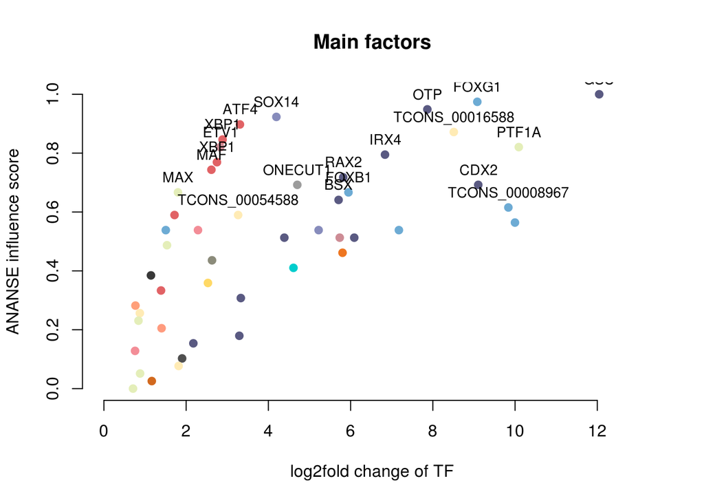

```r
plot(
  influ_tbl$factor_fc,
  influ_tbl$sumScaled,
  pch=19,
  col=influ_tbl$col,
  bg="black",
  xlab="log2fold change of TF",
  ylab="ANANSE influence score",
  main="Main factors",
  bty="n",
  xlim=c(0,max(influ_tbl$factor_fc)+1)
)
text(
  influ_tbl$factor_fc[1:20],
  influ_tbl$sumScaled[1:20],
  influ_tbl$genename[1:20],
  pos = 3,
  cex=0.85
)
```

And here is the plot of the graph of these TFs:

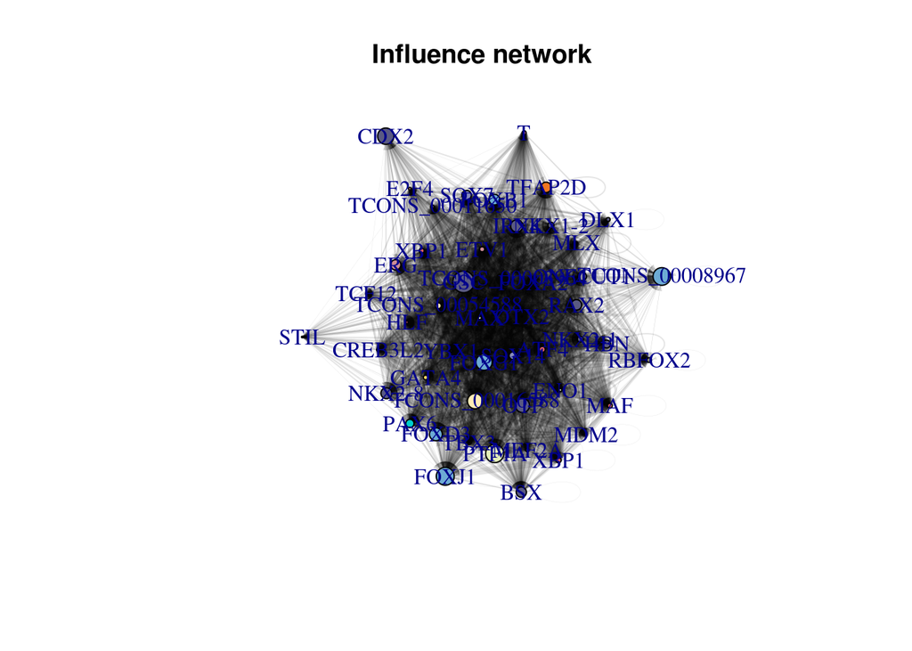

```r
V(EB_vs_LG$influence_graph)$genename <-
  translate_ids(V(EB_vs_LG$influence_graph)$name,pfla_genenames)

E(EB_vs_LG$influence_graph)$width <-
  category_by_quantile(
    E(EB_vs_LG$influence_graph)$prob,
    newvalues = c(0.2,1,2,5)
    )

plot(
  main = "Influence network",
  EB_vs_LG$influence_graph,
  vertex.color = V(EB_vs_LG$influence_graph)$col,
  vertex.label = V(EB_vs_LG$influence_graph)$genename,
  edge.width = E(EB_vs_LG$influence_graph)$width,
  edge.arrow.size = 0.2,
  edge.color = rgb(0,0,0,0.1),
  layout = layout_with_fr(EB_vs_LG$influence_graph)
)
```

## Genes in In Situs

Here there will be some code to subset the graphs and get the genes of each developmental layer.

## Networks from Other Organisms

Here there will be code to retrieve the subgraphs of genes from GRNs in other organisms.

## Save the Data

We will save the data now:

```r
save(
  # Attributes
  pfla_attributes_list,
  pfla_tfs_graph_analysis,
  pfla_tdhk,
  pfla_tfeg,
  pfla_funcat,
  # Early Blastula
  pfla_EB_nw,
  pfla_EB_nw2,
  pfla_EB_parsenetwork,
  pfla_EB_graph,
  pfla_EB_graph2,
  pfla_EB_stats,
  # Late Gastrula
  pfla_LG_nw,
  pfla_LG_nw2,
  pfla_LG_parsenetwork,
  pfla_LG_graph,
  pfla_LG_graph2,
  pfla_LG_stats,
  # Network comparison
  EB_vs_LG,
  file = "outputs/rda/graph_analysis.rda"
)
```